# **Ασκηση** 3

Χριστοδουλου Χρηστος ΑΜ 5392

## Ερωτηση 1

[figure not shown]

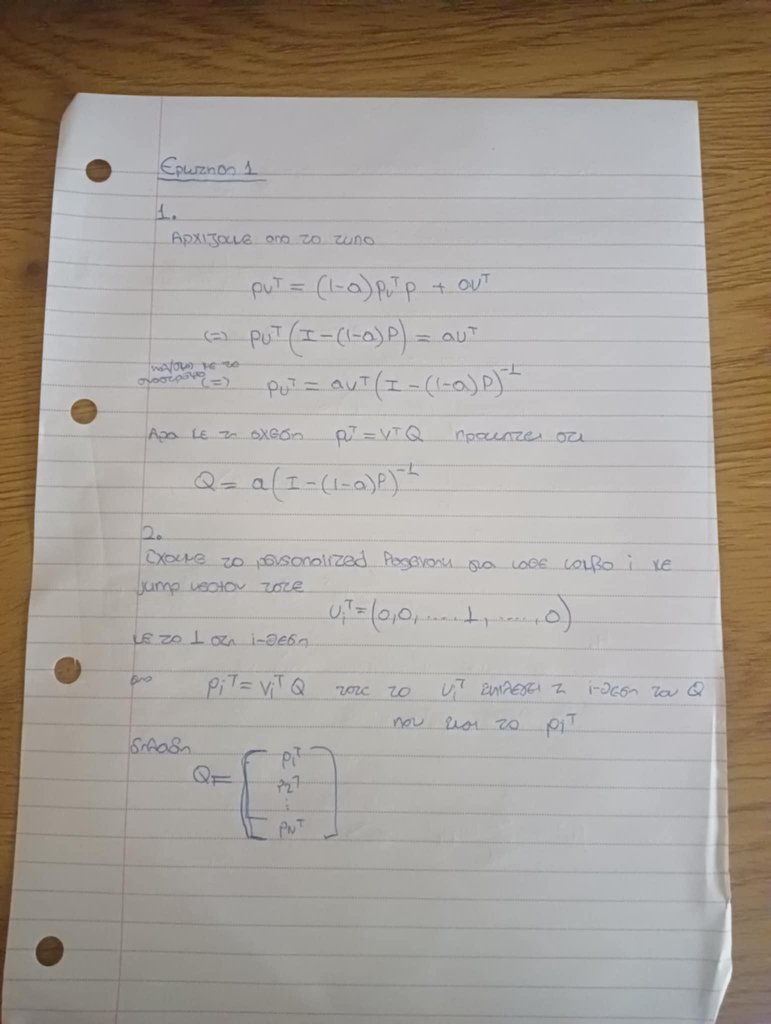

## Ερωτηση 2

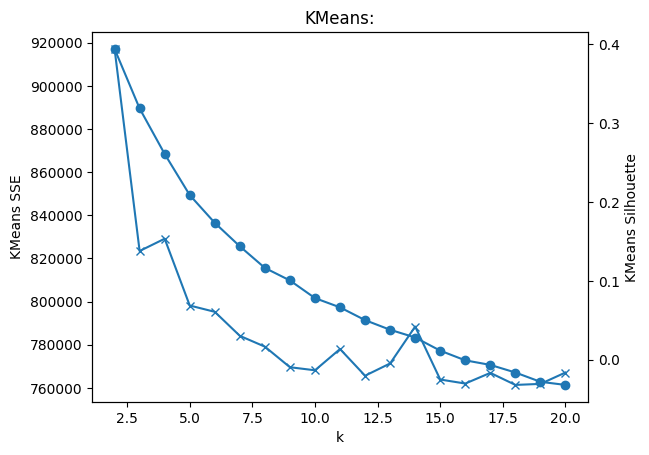

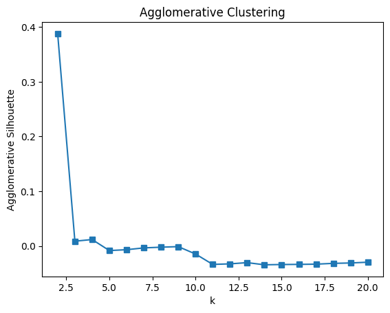

```
Cluster 0
War: lift=1.14
Romance: lift=1.09
History: lift=1.07

Cluster 1
Documentary: lift=2.34
Western: lift=1.64
Thriller: lift=1.38

Cluster 2
Animation: lift=1.84
Family: lift=1.54
War: lift=1.52

Cluster 3
Western: lift=1.65
Science Fiction: lift=1.29
Adventure: lift=1.14
```

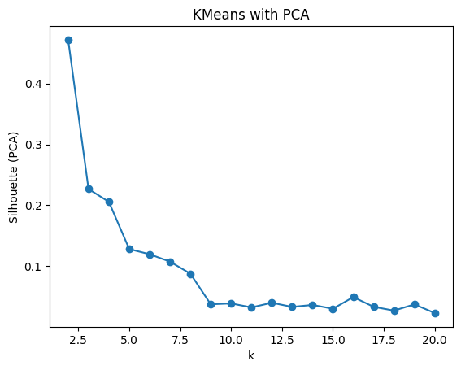

```
PCA Cluster 0
War: lift=1.17
Romance: lift=1.11
History: lift=1.10

PCA Cluster 1
Western: lift=1.55
Science Fiction: lift=1.25
Documentary: lift=1.16

PCA Cluster 2
Animation: lift=1.92
Family: lift=1.58
War: lift=1.50

PCA Cluster 3
Documentary: lift=2.32
Western: lift=1.63
Thriller: lift=1.39
```

```python
import pandas as pd
import numpy as np
import ast
import matplotlib.pyplot as plt

from scipy.sparse import csr_matrix
from sklearn.cluster import KMeans, AgglomerativeClustering
from sklearn.metrics import silhouette_score
from sklearn.decomposition import PCA
from collections import Counter

#reads from the files
ratings = pd.read_csv("ratings_small.csv")
links = pd.read_csv("links_small.csv")
movies = pd.read_csv("movies_metadata.csv", low_memory=False)

#convertions drop nan from links, convert to int
links = links.dropna(subset=["tmdbId"])
links["tmdbId"] = links["tmdbId"].astype(int)
movies["id"] = pd.to_numeric(movies["id"], errors="coerce")

#join ratings with link on the movieId
ratings = ratings.merge(links, on="movieId")

#join with movies on the tmbId
ratings = ratings.merge(movies, left_on="tmdbId", right_on="id")

movie_counts = ratings["movieId"].value_counts()
valid_movies = movie_counts[movie_counts >= 10].index
ratings = ratings[ratings["movieId"].isin(valid_movies)]  #get movies only with count>=10

#convert to cat-codes for every time
user_codes = ratings["userId"].astype("category").cat.codes
movie_codes = ratings["movieId"].astype("category").cat.codes

#make sparse array of (movie,user)(ratings)
R = csr_matrix(
    (ratings["rating"], (movie_codes, user_codes))
)

ks = range(2, 21)

kmeans_sse = []
kmeans_sil = []
agg_sil = []
#for every k in ks we do the kmeans algo and the agglomerative

for k in ks:
    km = KMeans(n_clusters=k, random_state=42, n_init=10)
    labels_km = km.fit_predict(R)

    kmeans_sse.append(km.inertia_)
    kmeans_sil.append(silhouette_score(R, labels_km))

    agg = AgglomerativeClustering(n_clusters=k, linkage="ward")
    labels_agg = agg.fit_predict(R.toarray())

    agg_sil.append(silhouette_score(R.toarray(), labels_agg))

#plot the 2 functions
fig, ax1 = plt.subplots()

ax1.plot(ks, kmeans_sse, marker="o")
ax1.set_xlabel("k")
ax1.set_ylabel("KMeans SSE")

ax2 = ax1.twinx()
ax2.plot(ks, kmeans_sil, marker="x")
ax2.set_ylabel("KMeans Silhouette")

plt.title("KMeans:")
plt.show()

plt.plot(ks, agg_sil, marker="s")
plt.xlabel("k")
plt.ylabel("Agglomerative Silhouette")
plt.title("Agglomerative Clustering")
plt.show()



#best k for the clusters
BEST_K=4


movie_df = ratings[["movieId"]].drop_duplicates().reset_index(drop=True)

kmeans = KMeans(n_clusters=BEST_K, random_state=42, n_init=10)
movie_df["cluster"] = kmeans.fit_predict(R)

ratings = ratings.merge(movie_df, on="movieId", how="left")

def parse_genres(x):
    try:
        return [g["name"] for g in ast.literal_eval(x)]
    except:
        return []


ratings["genres_list"] = ratings["genres"].apply(parse_genres)

def genre_lift(df, label_col):
    all_genres = Counter()
    for gs in df["genres_list"]:
        all_genres.update(gs)

    total = sum(all_genres.values())
    results = {}

    for c in sorted(df[label_col].unique()):
        sub = df[df[label_col] == c]
        cnt = Counter()

        for gs in sub["genres_list"]:
            cnt.update(gs)

        cluster_total = sum(cnt.values())

        lift = {
            g: (cnt[g] / cluster_total) / (all_genres[g] / total)
            for g in cnt
        }

        results[c] = sorted(lift.items(), key=lambda x: x[1], reverse=True)[:3]

    return results

lift_results = genre_lift(ratings, "cluster")

for c, gs in lift_results.items():
    print(f"\nCluster {c}")
    for g, l in gs:
        print(f"{g}: lift={l:.2f}")


pca = PCA(n_components=50, random_state=42)
R_pca = pca.fit_transform(R.toarray())

pca_sil = []

for k in ks:
    km = KMeans(n_clusters=k, random_state=42, n_init=10)
    labels = km.fit_predict(R_pca)
    pca_sil.append(silhouette_score(R_pca, labels))

plt.plot(ks, pca_sil, marker="o")
plt.xlabel("k")
plt.ylabel("Silhouette (PCA)")
plt.title("KMeans with PCA")
plt.show()

kmeans_pca = KMeans(n_clusters=BEST_K, random_state=42, n_init=10)
movie_df["cluster_pca"] = kmeans_pca.fit_predict(R_pca)

ratings = ratings.merge(
    movie_df[["movieId", "cluster_pca"]],
    on="movieId",
    how="left"
)

lift_pca = genre_lift(ratings, "cluster_pca")

for c, gs in lift_pca.items():
    print(f"\nPCA Cluster {c}")
    for g, l in gs:
        print(f"{g}: lift={l:.2f}")
```

# Σχολιάσμος Ερωτησης 2

# Συμπεράσματα Ομαδοποίησης Ταινιών

Στην άσκηση αυτή ομαδοποιήσαμε ταινίες με βάση τις αξιολογήσεις των χρηστών. Αφού κρατήσαμε μόνο τις ταινίες με τουλάχιστον 10 ratings και δημιουργήσαμε τον sparse πίνακα, εφαρμόσαμε δύο αλγορίθμους για k από 2 έως 20.

1. Ανάλυση K-Means Για τον K-Means φτιάξαμε ένα γράφημα με δύο άξονες (SSE και Silhouette) για να δούμε πώς συμπεριφέρεται το μοντέλο.SSE (Sum of Squared Errors): Βλέπουμε ότι η καμπύλη πέφτει συνεχώς καθώς αυξάνεται το k. Δεν υπάρχει κάποιος πολύ καθαρός «αγκώνας» (elbow point), κάτι που συμβαίνει συχνά σε αραιά δεδομένα όπως τα ratings ταινιών.Silhouette Score: Εδώ η εικόνα είναι πιο ξεκάθαρη. Έχουμε την υψηλότερη τιμή στο k=2 (περίπου 0.39). Παρατηρούμε επίσης μια μικρή άνοδο στο k=4, αλλά μετά το 5 το σκορ πέφτει σταδιακά.Underfitting & Overfitting:Underfitting: Αν διαλέγαμε k=1, το μοντέλο θα ήταν πολύ απλό και δεν θα έβλεπε καμία διαφορά μεταξύ των ταινιών.Overfitting: Για k>4, το SSE συνεχίζει να πέφτει, αλλά το Silhouette Score πλησιάζει το μηδέν. Αυτό σημαίνει ότι ο αλγόριθμος αρχίζει να «σπάει» τις φυσικές ομάδες σε υπερβολικά πολλές μικρές κατηγορίες που δεν έχουν πραγματικό νόημα, μοντελοποιώντας ουσιαστικά τον θόρυβο των δεδομένων.
2. Ανάλυση Agglomerative Clustering

   Στον ιεραρχικό αλγόριθμο, βασιστήκαμε στο Silhouette Score για να δούμε την ποιότητα των clusters.Αποτέλεσμα: Η κορυφή είναι πάλι στο k=2. Είναι το σημείο όπου οι ταινίες διαχωρίζονται με τον πιο καθαρό τρόπο.Πτώση Ποιότητας: Μετά το k=2, το σκορ πέφτει σχεδόν στο μηδέν. Αυτό δείχνει ότι η ιεραρχική δομή των ratings ευνοεί τη δημιουργία δύο μεγάλων κατηγοριών.Overfitting: Ο αλγόριθμος είναι πολύ ευαίσθητος στην υπερπροσαρμογή. Για k >10, οι τιμές Silhouette γίνονται αρνητικές. Αυτό είναι «καθαρό» overfitting: ο αλγόριθμος αναγκάζεται να φτιάξει τόσα πολλά clusters που τελικά βάζει ταινίες σε λάθος ομάδες (πιο κοντά σε γειτονικά clusters παρά στο δικό τους).
3. Σύγκριση και Τελική Επιλογή

   Συγκρίνοντας τους δύο αλγορίθμους, ο K-means προσφέρει μεγαλύτερη ευκρίνεια για την τελική απόφαση, καθώς η ταυτόχρονη απεικόνιση του SSE και του Silhouette Score επιτρέπει την καλύτερη κατανόηση της δομής των δεδομένων. Παρόλο που το Silhouette Score κορυφώνεται στο k=2 και στους δύο αλγορίθμους, επιλέγουμε τελικά το k=4 ως τον βέλτιστο αριθμό ομάδων. Η επιλογή αυτή βασίζεται στο γεγονός ότι στον K-means, στο k=4 το SSE έχει μειωθεί σημαντικά σε σχέση με το k=2, ενώ το Silhouette Score παραμένει σε ικανοποιητικά επίπεδα, εξασφαλίζοντας ουσιαστικό διαχωρισμό χωρίς τον κίνδυνο ακραίας υπερπροσαρμογής (overfitting). Αντίθετα, ο Agglomerative αλγόριθμος αποδεικνύεται λιγότερο κατατοπιστικός, καθώς η απότομη πτώση του Silhouette αμέσως μετά το k=2 καθιστά την επιλογή περισσότερων clusters στατιστικά αβέβαιη σε σχέση με την πιο πλήρη εικόνα που δίνει ο K-means.
4. Χρηση lift και PCA για αξιολογηση των ειδων

   Για την αξιολόγηση των clusters χρησιμοποιήθηκαν τα genres των ταινιών που ανήκουν σε κάθε ομάδα. Αν και η απλή συχνότητα των genres μπορεί να δώσει μια πρώτη εικόνα, συχνά ευνοεί τα πιο δημοφιλή είδη και δεν αποτυπώνει σωστά τι είναι πραγματικά χαρακτηριστικό για κάθε cluster. Για τον λόγο αυτό χρησιμοποιήθηκε το lift, το οποίο δείχνει πόσο συχνότερα εμφανίζεται ένα genre σε ένα cluster σε σχέση με το σύνολο των δεδομένων. Με βάση τα τρία genres με το μεγαλύτερο lift, τα clusters αποδείχθηκαν θεματικά συνεπή: προέκυψαν ομάδες με ιστορικό και δραματικό χαρακτήρα (War, Romance, History), ομάδες με πιο «σκληρό» και ρεαλιστικό περιεχόμενο (Documentary, Thriller, Western), οικογενειακές και εκπαιδευτικές ταινίες (Animation, Family), καθώς και ταινίες δράσης και φαντασίας (Science Fiction, Adventure, Western). Αυτό δείχνει ότι η ομαδοποίηση είναι ερμηνεύσιμη και όχι τυχαία.Η ίδια διαδικασία εφαρμόστηκε μετά από μείωση διάστασης με PCA, κρατώντας τους 50 ισχυρότερους latent factors. Τα αποτελέσματα παρέμειναν σε μεγάλο βαθμό σταθερά, με μικρές μόνο ανακατατάξεις, γεγονός που υποδηλώνει ότι το PCA δεν αλλοίωσε τη δομή των clusters αλλά βοήθησε στη μείωση του θορύβου. Ως εναλλακτικοί τρόποι αξιολόγησης θα μπορούσαν να χρησιμοποιηθούν και άλλα χαρακτηριστικά των ταινιών, όπως tags ή περιγραφές μέσω NLP, καθώς και ποσοτικές μετρικές όπως το Silhouette score, ώστε να συνδυαστεί η ερμηνευσιμότητα με αντικειμενικά κριτήρια ποιότητας.

# Ερωτηση 3

```python
import pandas as pd
import numpy as np
import ast
import matplotlib.pyplot as plt
from sklearn.model_selection import cross_val_predict,cross_validate
from sklearn.metrics import confusion_matrix, accuracy_score, precision_score, recall_score

def evaluate_model(model, X, y, cv, labels, name):
    y_pred = cross_val_predict(model, X, y, cv=cv)

    acc = accuracy_score(y, y_pred)
    prec = precision_score(y, y_pred, average='macro')
    rec = recall_score(y, y_pred, average='macro')
    cm = confusion_matrix(y, y_pred, labels=labels)

    print(f"\n===== {name} =====")
    print(f"Accuracy : {acc:.3f}")
    print(f"Precision: {prec:.3f}")
    print(f"Recall   : {rec:.3f}")
    print("Confusion Matrix:")
    print(cm)

    return acc, prec, rec, cm


movies =pd.read_csv("movies_metadata.csv", low_memory=False)
movies = movies[['overview', 'genres']]

movies = movies.dropna(subset=['genres', 'overview'])

movies['genres']=movies['genres'].apply(ast.literal_eval)

movies['name_gen']=movies['genres'].apply(lambda x:[g['name'] for g in x])

movies_gen_final={'War','Music','Animation'}

#only or more one genre
movies = movies[movies['name_gen'].apply(
    lambda x: len(movies_gen_final.intersection(x))>0
)]

#clean and hold only the movie_gen_final
movies = movies[movies['name_gen'].apply(
    lambda x: len(movies_gen_final.intersection(x))==1
)]


movies['label'] = movies['name_gen'].apply(
    lambda x: list(movies_gen_final.intersection(x))[0]
)

movies = movies[['overview', 'label']]


#TF-IDF IMPLEMENTATION

from sklearn.feature_extraction.text import TfidfVectorizer
from sklearn.model_selection import StratifiedKFold
from sklearn.pipeline import Pipeline


x =movies['overview']
y =movies['label']

tfidf = TfidfVectorizer(max_features=5000,stop_words='english')

cv=StratifiedKFold(n_splits=5,shuffle=True,random_state=42)

#classifiers
from sklearn.tree import DecisionTreeClassifier
from sklearn.neighbors import KNeighborsClassifier
from sklearn.linear_model import LogisticRegression
from sklearn.svm import LinearSVC
from sklearn.neural_network import MLPClassifier

classifiers = {
    "Decision Tree": DecisionTreeClassifier(random_state=42),
    "kNN": KNeighborsClassifier(n_neighbors=4),
    "Logistic Regression": LogisticRegression(max_iter=1000),
    "SVM": LinearSVC(),
    "MLP": MLPClassifier(hidden_layer_sizes=(100,), max_iter=500)
}



labels = sorted(movies_gen_final)


for name, clf in classifiers.items():

    pipeline = Pipeline([
        ('tfidf', tfidf),
        ('clf', clf)
    ])

    evaluate_model(
        pipeline,
        x,          # overviews
        y,          # labels
        cv,
        labels,
        f"TF-IDF + {name}"
    )




#word-2-vec
!pip install --upgrade gensim
import gensim
import gensim.downloader as api

w2v_model = api.load("glove-wiki-gigaword-50")

import re

def preprocess_text(text):
    text = text.lower()
    text = re.sub(r'[^a-z ]','',text)
    return text.split()

def get_mean_vector(text, model, vector_size=50):
    words = preprocess_text(text)

    vectors = [
        model[word] for word in words
        if word in model
    ]

    if len(vectors) == 0:
        return np.zeros(vector_size)

    return np.mean(vectors, axis=0)

X_w2v = np.vstack(
    movies['overview'].apply(
        lambda x: get_mean_vector(x, w2v_model)
    )
)

y = movies['label']


for name, clf in classifiers.items():

    evaluate_model(
        clf,
        X_w2v,     # Word2Vec features
        y,
        cv,
        labels,
        f"Word2Vec + {name}"
    )
```

```
===== TF-IDF + Decision Tree =====
Accuracy : 0.739
Precision: 0.743
Recall   : 0.746
Confusion Matrix:
[[1254  409  174]
 [ 258 1148  104]
 [ 146  117 1020]]

===== TF-IDF + kNN =====
Accuracy : 0.700
Precision: 0.709
Recall   : 0.705
Confusion Matrix:
[[1149  433  255]
 [ 182 1203  125]
 [  91  304  888]]

===== TF-IDF + Logistic Regression =====
Accuracy : 0.873
Precision: 0.882
Recall   : 0.869
Confusion Matrix:
[[1691  103   43]
 [ 223 1248   39]
 [ 117   64 1102]]

===== TF-IDF + SVM =====
Accuracy : 0.865
Precision: 0.868
Recall   : 0.865
Confusion Matrix:
[[1629  141   67]
 [ 195 1244   71]
 [  82   67 1134]]

===== TF-IDF + MLP =====
Accuracy : 0.850
Precision: 0.851
Recall   : 0.850
```

[output cut: 28 more lines]

```
Precision: 0.855
Recall   : 0.853
Confusion Matrix:
[[1585  146  106]
 [ 192 1256   62]
 [ 108   67 1108]]

===== Word2Vec + SVM =====
Accuracy : 0.855
Precision: 0.857
Recall   : 0.855
Confusion Matrix:
[[1590  139  108]
 [ 196 1249   65]
 [ 102   60 1121]]
```

```
===== Word2Vec + MLP =====
Accuracy : 0.841
Precision: 0.843
Recall   : 0.843
Confusion Matrix:
[[1557  155  125]
 [ 222 1218   70]
 [ 104   58 1121]]
```

# Συμπεράσματα και σχολιασμός αποτελεσμάτων (Ερώτηση 3)

# TF-IDF // Word2Vec

Τα decision trees δε απεδωσαν καθολου καλα και στους 2 αλγοριθμους οπως φαινεται με accuracy(tf-idf)=0.73 ,accuracy(word2vec)=0.682 και οπως φαινεται απο τα confusion-matrixs δείχνουν αυξημένες συγχύσεις μεταξύ των κλάσεων που δυσκολεύεται να διαχειριστεί τη μεγάλη διάσταση και το θόρυβο των χαρακτηριστικών.

Στο ΚΝΝ TF-IDF είχε χαμηλή απόδοση accuracy=0.70 και στο word2vec βελτιώθηκε αισθητά accuracy=0.792 το οποιο δειχνει οτι ο kNN λειτουργεί καλύτερα σε πυκνά, χαμηλότερης διάστασης διανύσματα (Word2Vec) αρά σε sparse αναπαραστάσεις όπως το TF-IDF.

Στο MLP παρουσιαστηκε σχετικα παρομοια σταθερη καλη αποδοση με tf-idf=0.85 ,word2vec=0.841 αλλα απο τα warnings φανηκε οτι δε συγκλινει οποτε δε φτανει στην καλυτερη του αποδοση εκτος αν γινοταν καλυτερη αλλαγη μεταβλητων και των εποχων.

# Ερωτηση 4

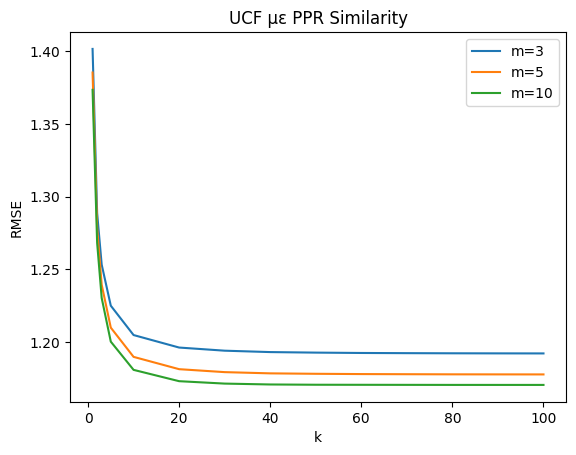

```python
import pandas as pd
import numpy as np
import networkx as nx
import matplotlib.pyplot as plt

from sklearn.metrics.pairwise import cosine_similarity
from sklearn.model_selection import train_test_split
from sklearn.metrics import mean_squared_error

ratings = pd.read_csv("ratings_small.csv")

train, test = train_test_split(
    ratings, test_size=0.2, random_state=42
)


R = train.pivot_table(
    index="userId",
    columns="movieId",
    values="rating"
).fillna(0)


cos_sim = cosine_similarity(R)
users = R.index.tolist()


def build_user_graph(cos_sim, users, m):
    G = nx.Graph()

    for i, u in enumerate(users):
        sims = list(enumerate(cos_sim[i]))
        sims = sorted(sims, key=lambda x: x[1], reverse=True)

        count = 0
        for j, s in sims:
            if i != j and count<m:
                v = users[j]
                if not G.has_edge(u, v):
                    G.add_edge(u, v, weight=s)
                count += 1
    return G

def compute_ppr(G, user):
    pers = {n: 0 for n in G.nodes()}
    pers[user] = 1
    return nx.pagerank(G, alpha=0.85, personalization=pers, weight="weight")

def predict_rating(user, movie, R, ppr_scores, k):
    if movie not in R.columns:
        return R.values.mean()

    sims = []
    for v in ppr_scores:
        if R.loc[v, movie] > 0 and v != user:
            sims.append((v, ppr_scores[v]))

    sims = sorted(sims, key=lambda x: x[1], reverse=True)[:k]

    num, den = 0, 0
    for v, s in sims:
        num += s * R.loc[v, movie]
        den += abs(s)

    if den == 0:
        return R.values.mean()

    return num / den

def compute_rmse(test, R, ppr_all, k):
    preds, real = [], []

    for _, row in test.iterrows():
        u, m, r = row["userId"], row["movieId"], row["rating"]

        if u not in R.index:
            continue

        p = predict_rating(u, m, R, ppr_all[u], k)
        preds.append(p)
        real.append(r)

    return np.sqrt(mean_squared_error(real, preds))

m_values = [3, 5, 10]
k_values =  [1,2,3,5,10,20,30,40,50,60,70,80,90,100]

results = {}

for m in m_values:
    G = build_user_graph(cos_sim, users, m)

    ppr_all = {}
    for u in users:
        ppr_all[u] = compute_ppr(G, u)

    rmses = []
    for k in k_values:
        rmse = compute_rmse(test, R, ppr_all, k)
        rmses.append(rmse)

    results[m] = rmses


for m in m_values:
    plt.plot(k_values, results[m], label=f"m={m}")

plt.xlabel("k")
plt.ylabel("RMSE")
plt.legend()
plt.title("UCF με PPR Similarity")
plt.show()
```

# Σχολιασμος Αποτελεσματων Ερωτησης 4

Στο συγκκεριμενο ερωτημα λοιπον δημιουρηθηκε ενα γραφημα χρηστων-ταινιων κατα το οποιο συνδεεται με τους m ποιο ομοιους τους γειτονες-χρηστες με ως μετρο το cosine-similarity και για καθε χρηστη υπολογιζεται το ppr ως μετρο συγκρισης και ομοιοτητας με το αλγοριθμο του ucf.

Παραηρουμε λοιπον οτι για τιμη m=3 το rmse με μικρο αριθμο γειτονων για ομαδοποιηση (κ) αποτελει πολυ μεγαλο αριθμο λογω του αραιου data,πληροφοριων που εχουμε, που θα εχουμε και οσο αυξανεται το κ εχουμε μια αποτομη μειωση ως προς το 1.2 πιο κοντα.Οσο μεγαλωνει η τιμη του m[5,10] ομως φαινεται οτι το rmse εχει πιο μικρα μεγιστα στη αρχη με πολυ μικρα κ και οσο παει πεφτει μεχρι να σταθεροποιηθει σε μια τιμη και αυτο οφειλεται οτι ο πινακας αρχιζει να γινεται πιο πυκνος.Το Personalized PageRank είναι αποτελεσματικό για την ανίχνευση πιο σχετικών γειτόνων στο UCF και η παραμετρος m επηρεαζει τα αποτελεσματα σημαντικα ως προς την ακριβεια με μικρες τιμες-->μικροτερη διαδοση πληροφοριας αρα μεγαλυτερο σφαλμα και μεγαλες τιμες-->επιτρεπουν καλυτερη διαδοση της ομοιοτητας.Τελος σε συγκριση με την ασκηση 2 για το αποτελεσμα του ucf βρηκαμε ως ελαχιστο rmse 0.9700 για κ=30 γειτονες αλλα σε συγκριση με τη υλοποιηση με ppr παρατηρουμε οτι εχει μεγαλυτερο σφαλμα για τις συγκρεκριμενες τιμες λογω της πολυπλοκοτητας της διαδικασιας του γραφου και υπολογιστικα πιο απαιτητικη.